# My Exercise 1

Rockefeller University, Bioinformatics Resource Centre

https://rockefelleruniversity.github.io/RU_course_template/

These exercises are about [building basic apps, app layouts, and themes](https://rockefelleruniversity.github.io/RU_shiny/).

**Exercises for Shiny session 1**

1. Make an app that reads in the table in the ‘data’ folder of the course materials that has a file name of ‘msk_2024_clinical_Pancreatic_rev.csv’ and displays that table on the page.
2. Add some figures to the page, including a plot that:
- displays a histogram showing the distribution of the ages of patients
- displays three pie charts showing the break down of the following columns: Sex, Sample_Type, and Smoking_History_NLP
- displays one Kaplan Meier survival curve showing any difference in survival based on the Smoking_History_NLP column
  - HINT: see sample code below for how to make a histogram, pie chart, and survival curve in the code chunk below.
- Put the table and plots in separate cards and make the card that has the table collapseable.

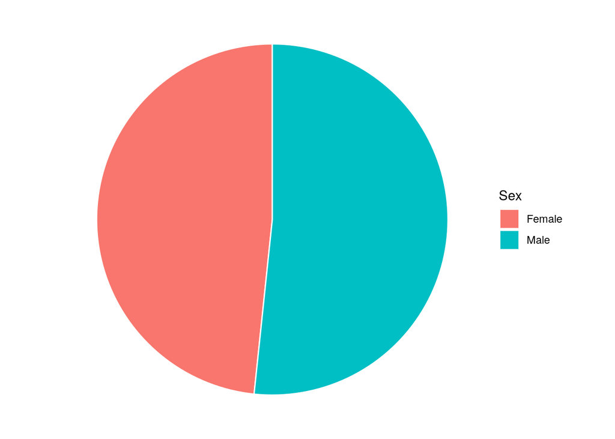

```r
data_in <- rio::import("data/msk_2024_clinical_Pancreatic_rev.csv")

# Sample code for pie chart:
library(ggplot2)
library(dplyr)

data_in %>%
  group_by(Sex) %>%
  summarize(Num = n()) %>%
  ggplot(aes(x = 1, y = Num, fill = Sex)) +
  geom_bar(stat="identity", color="white") +
  coord_polar("y") + theme_void()
```

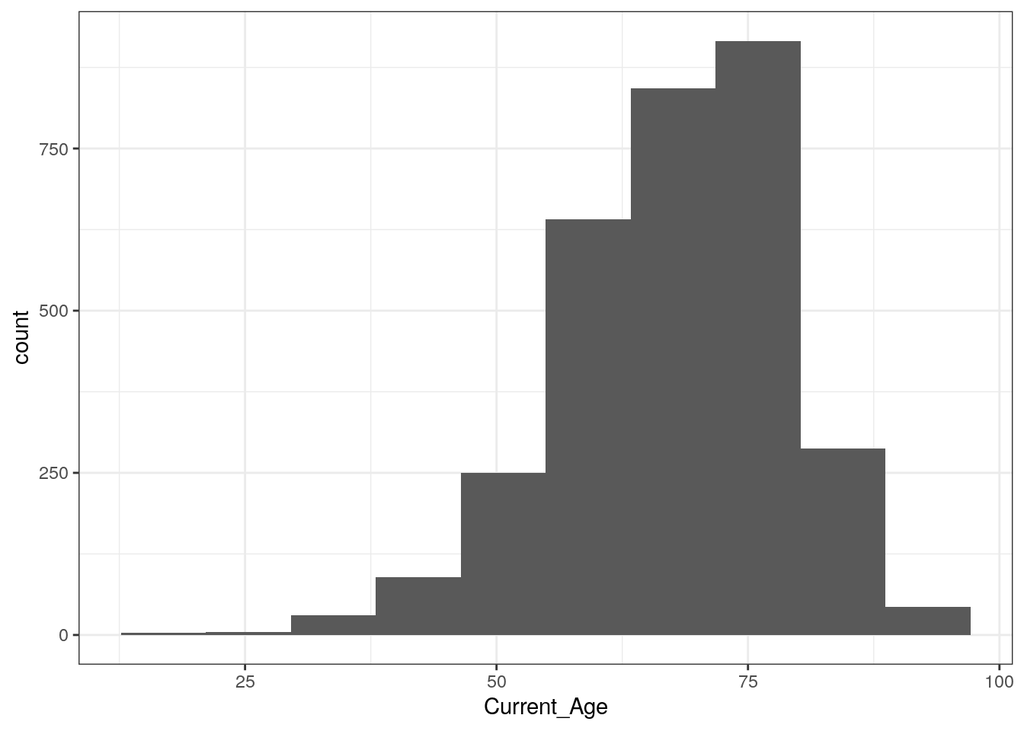

```r
# Sample code for histogram:
ggplot(data_in, aes(x = Current_Age)) +
      geom_histogram(bins=10) +
      theme_bw()
```

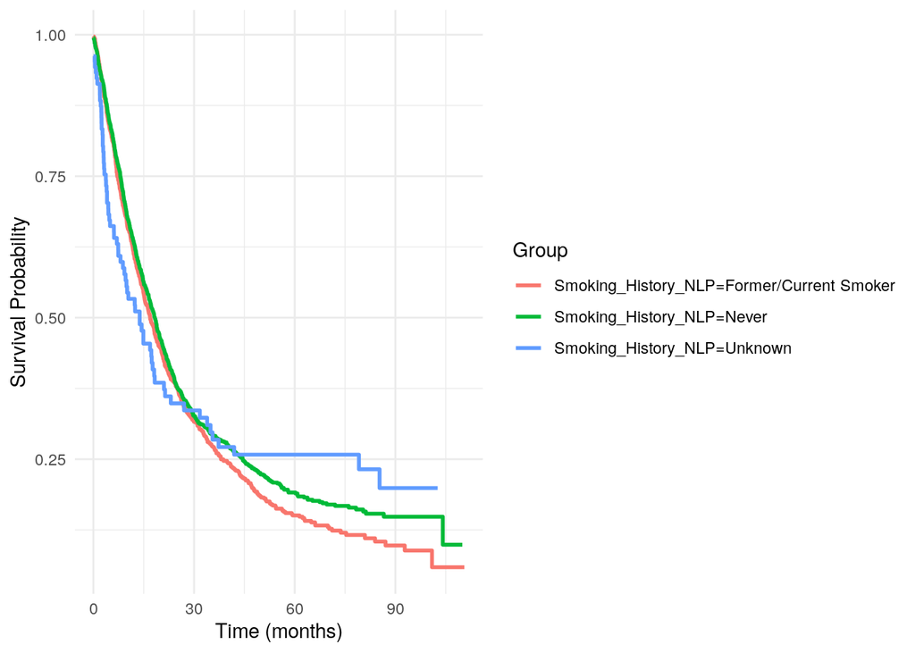

```r
# Sample code for survival analysis:
library(survival)

surv_obj <- Surv(time = data_in$Overall_Survival_Months, event = data_in$Survival_code)
fit <- survfit(surv_obj ~ Smoking_History_NLP, data = data_in)
surv_df <- data.frame(
  time = fit$time,
  surv = fit$surv,
  group = rep(names(fit$strata), fit$strata)
)

ggplot(surv_df, aes(x = time, y = surv, color = group)) +
  geom_step(linewidth = 1) +
  labs(x = "Time (months)", y = "Survival Probability", color = "Group") +
  theme_minimal()
```

3. Make the app have multiple pages, with the first page containing all of the plots and the second page containing the table.
- For the page with the plots, try various layouts with at least one row having multiple columns and pick your favorite layout.
- add a menu panel on the right side of the nav bar with a link to the page where these data came from, https://www.cbioportal.org/
- since the table and plots are now on separate pages, add a *value_box* to the page with the plots to let the user quickly know the number of patients in this study.
- Try a couple of different themes and pick one. Remember that you often need to restart your R session to clear the cache and reset the theme.